# Time dependent AUC with survival data _ correct6-3

Hwang Seong-Yun

2022 5 23

# Loading packages

```r
library(survival)
library(timeROC)
library(timereg)
library(ggplot2)
library(reshape)
library(plyr)
library(tidyverse)
library(coxed)
library(gridExtra)
library(mgcv)
```

# Generating simulation data from Cox Regression Model

## Background

- reference 1 : https://doi.org/10.5351/KJAS.2018.31.6.761
- reference 2 : https://doi.org/10.1017/psrm.2018.19

`-` Parametric basis distribution

- real survival time $Y$ : Exponential distribution
- censoring time $C$ : Uniform distribution
- $h(t|x)=h_{0}(t)exp(f(x))$
- $H(t|x)=\int_{0}^{t} h(s|x)ds= \int_{0}^{t} h_{0}(s)exp(f(x))ds=H_{0}(t)exp(f(x))$
- $h(t|x)=\frac {f(t|x)}{S(t|x)}= -\frac {d}{dt} log[S(t|x)]$
- $log[S(t|x)]= -\int_{0}^{t} h(s|x)ds= -H(t|x)= -H_{0}(t)exp(f(x))$
- $S(t|x)=exp[-H_{0}(t)exp(f(x))]$
- In general,…
- $F(t|x)=1-exp[-H_{0}(t) exp(f(x))]$
- -> $F^{-1}(t|x)=H_{0}^{-1}[-log(1-t) exp(-f(x))]$
- By Inverse Transform Sampling, suppose that $U_{1}, U_{2} \overset{i.i.d}{\sim}\ U(0,1)$, then we can generate real survival time $Y$ from Cox Regression Model using this equation.
- $Y=H_{Y0}^{-1}[-log(U_{1})exp(-f(x))]$
- And by assuming non-informative censoring, we can generate censoring time $C$ like this equation. (Set $Y$ and $C$ are independent each other.)
- $C=H_{C0}^{-1}[-log(U_{2})]$
- And set censoring indicator $\delta=I(Y \leq C)$ and observed survival time $T=min(Y,C)$
- $H_{Y0}(t)$ : Basis cumulative hazard function of real survival time $Y$
- $H_{C0}(t)$ : Basis cumulative hazard function of censoring time $C$
- When parametric basis distribution of real survival time $Y$ is Exponential distribution and parametric basis distribution of censoring time $C$ is Uniform distribution ($Y$ and $C$ are independent each other), then ~
- $Y$ : $f_{Y0}(t)=\lambda e^{-\lambda t}, t>0$ -> $S_{Y0}(t)=e^{-\lambda t}$ -> $h_{Y0}(t)=\lambda$
- $C$ : $f_{C0}(t)=\frac {1}{\lambda}, 0<t<\lambda$ -> $S_{C0}(t)=1-\frac {t}{\lambda}$ -> $h_{C0}(t)=\frac {1}{\lambda -t}$
- $\therefore Y=-\frac{1}{\lambda_{1}} log(U_{1}) exp(-f(x))$, $C=\lambda_{2}(1-U_{2})$

# Generate survival data with time dependent covariates

## Background

- reference 1 : https://doi.org/10.1002/sim.5452
- reference 2 : https://dx.doi.org/10.21037/atm.2018.02.12

## Case 1) Continuous time-varying covariate: exponential distribution of event times

- $Y$ : real survival time
- $C$ : censoring time
- model : $h(t,x,z(t))=h_{0}(t)exp(\beta x + \gamma z(t))$
- $Y$ : Assume $z(t)=\alpha t$, $\alpha > 0$
- $h_{0}(t)=\lambda$
- $h(t,x,z(t))=\lambda exp(\beta x + \gamma \alpha t)=-\frac{d}{dt} log[S(t,x,z(t))]$
- $log[S(t,x,z(t))]=-\int_{0}^{t}\lambda exp(\beta x + \gamma \alpha s)ds=-\frac{\lambda exp(\beta x)}{\gamma \alpha} [exp(\gamma \alpha t)-1]$
- $S(t,x,z(t))=exp[-\frac{\lambda exp(\beta x)}{\gamma \alpha} [exp(\gamma \alpha t)-1]]$
- $F(t,x,z(t))=1-exp[-\frac{\lambda exp(\beta x)}{\gamma \alpha} [exp(\gamma \alpha t)-1]]$
- $F^{-1}(t,x,z(t))=\frac {1}{\gamma \alpha} log[1-\frac {\gamma \alpha}{\lambda exp(\beta x)} log(1-t)]$
- $C$ : $f_{C0}(t)=\frac {1}{\lambda}, 0<t<\lambda$ -> $S_{C0}(t)=1-\frac {t}{\lambda}$ -> $h_{C0}(t)=\frac {1}{\lambda -t}$
- By Inverse Transform Sampling and non-informative censoring, suppose that $U_{1}, U_{2} \overset{i.i.d}{\sim}\ U(0,1)$, then we can generate real survival time $Y$ and censoring time $C$ like this.
- $\therefore Y=\frac {1}{\gamma \alpha} log[1-\frac {\gamma \alpha}{\lambda_{1} exp(\beta x)} log(U_{1})]$
- $\therefore C=\lambda_{2}(1-U_{2})$

## Example 1

## Generating simulation data

```r
lambda1 <- 0.003 # parameter for generate Y
lambda2 <- 0.2/lambda1 # parameter for generate C
beta0 <- -3 ; gamma0 <- 2 ; alpha0 <- 4 # true coefficients
Y <- c() # real survival time
C <- c() # censoring time
t <- c() # observed survival time
censor <- c() # censoring indicator
X <- c() # time invariant covariate
U1 <- c() # random variable from U(0,1) for generate Y
U2 <- c() # random variable from U(0,1) for generate C

for (i in 1:1000) {
  U1[i] <- runif(1)
  U2[i] <- runif(1)
  X[i] <- runif(1,min=0,max=1)
  Y[i] <- (1/gamma0*alpha0)*log(1-(gamma0*alpha0/lambda1/exp(beta0*X[i]))*log(U1[i]))
  C[i] <- (lambda2)*(1-U2[i])
  t[i] <- min(Y[i],C[i])
  censor[i] <- ifelse(Y[i]<=C[i],1,0)
}

mean(1-censor) # censoring rate
```

```
## [1] 0.244
```

```r
dt5 <- data.frame(X=X, Y=Y, C=C, time=t, censor=censor)
head(dt5,10)
```

```
##               X        Y         C      time censor
## 1  0.9878675116 22.97426 40.318449 22.974258      1
## 2  0.0001465895 13.60454  2.804069  2.804069      0
## 3  0.3411193388 18.62637 45.429980 18.626371      1
## 4  0.7297531392 20.17540 54.554108 20.175401      1
## 5  0.1825260546 12.73647 44.556709 12.736469      1
## 6  0.5192753468 19.52502 18.481305 18.481305      0
## 7  0.4672127704 18.59310 49.428344 18.593105      1
## 8  0.2537901362 17.42545 29.567560 17.425449      1
## 9  0.3846293399 20.43486 27.613392 20.434864      1
## 10 0.0450237128 15.42964 34.812119 15.429638      1
```

```r
min(dt5$time[dt5$censor==1])
```

```
## [1] 4.491509
```

### Time dependent AUC

### True model

- model : $h(t,x,z(t))=h_{0}(t)exp[\beta x + \gamma z(t)]$
- $z(t)=\alpha t$
- $h_{0}(t)=\lambda$
- True coefficients : $\beta=-3$, $\gamma=2$, $\alpha=4$

### Set Cox regression model

```r
cox.dep.dt5 <- coxph(Surv(time,censor) ~ X, data=dt5)
summary(cox.dep.dt5)
```

```
## Call:
## coxph(formula = Surv(time, censor) ~ X, data = dt5)
##
##   n= 1000, number of events= 756
##
##       coef exp(coef) se(coef)   z Pr(>|z|)
## X -3.06665   0.04658  0.16143 -19   <2e-16 ***
## ---
## Signif. codes:  0 '***' 0.001 '**' 0.01 '*' 0.05 '.' 0.1 ' ' 1
##
##   exp(coef) exp(-coef) lower .95 upper .95
## X   0.04658      21.47   0.03394   0.06391
##
## Concordance= 0.714  (se = 0.009 )
## Likelihood ratio test= 374.4  on 1 df,   p=<2e-16
## Wald test            = 360.9  on 1 df,   p=<2e-16
## Score (logrank) test = 392  on 1 df,   p=<2e-16
```

```r
risk.dep.dt5 <- predict(object=cox.dep.dt5, newdata=dt5, type="risk") # risk score
dt5$risk.dep.dt5 <- risk.dep.dt5
ROC.risk.dep.dt5 <- timeROC(T=dt5$time,
                         delta=dt5$censor,marker=dt5$risk.dep.dt5,
                         cause=1,weighting="marginal",
                         times=dt5$time)
ROC.risk.dep.dt5
```

```
## Time-dependent-Roc curve estimated using IPCW  (n=1000, without competing risks).
##                     Cases Survivors Censored AUC (%)
## t=0.012610200792551     0       999        1      NA
## t=13.2272311302862     70       749      181   76.10
## t=16.8212714935116    280       500      220   78.75
## t=19.1630700883804    513       250      237   80.96
## t=24.6035896307529    755         0      245      NA
##
## Method used for estimating IPCW:marginal
##
## Total computation time : 0.46  secs.
```

#### Make AUC data

```r
# uncensored
uncensored.density5 <- density(dt5$time[dt5$censor==1])
data5_1 <- data.frame(time=uncensored.density5[["x"]],
                    density=uncensored.density5[["y"]])
data5_1$density.adjusted <- (max(na.omit(ROC.risk.dep.dt5[["AUC"]]))-min(na.omit(ROC.risk.dep.dt5[["AUC"]])))*(uncensored.density5[["y"]]-min(uncensored.density5[["y"]]))/(max(uncensored.density5[["y"]])-min(uncensored.density5[["y"]]))+min(na.omit(ROC.risk.dep.dt5[["AUC"]]))

# censored
censored.density5 <- density(dt5$time[dt5$censor==0])
data5_2 <- data.frame(time=censored.density5[["x"]],
                    density=censored.density5[["y"]])
data5_2$density.adjusted <- (max(na.omit(ROC.risk.dep.dt5[["AUC"]]))-min(na.omit(ROC.risk.dep.dt5[["AUC"]])))*(censored.density5[["y"]]-min(censored.density5[["y"]]))/(max(censored.density5[["y"]])-min(censored.density5[["y"]]))+min(na.omit(ROC.risk.dep.dt5[["AUC"]]))

res5 <- data.frame(time=ROC.risk.dep.dt5[["times"]],
                    cox.dep.dt5=ROC.risk.dep.dt5[["AUC"]])
res5 <- melt(data = res5,
                   id.vars = "time",
                   measure.vars = c("cox.dep.dt5"))
```

#### Time dependent AUC plot with ggplot2 (cox.dep.dt5)

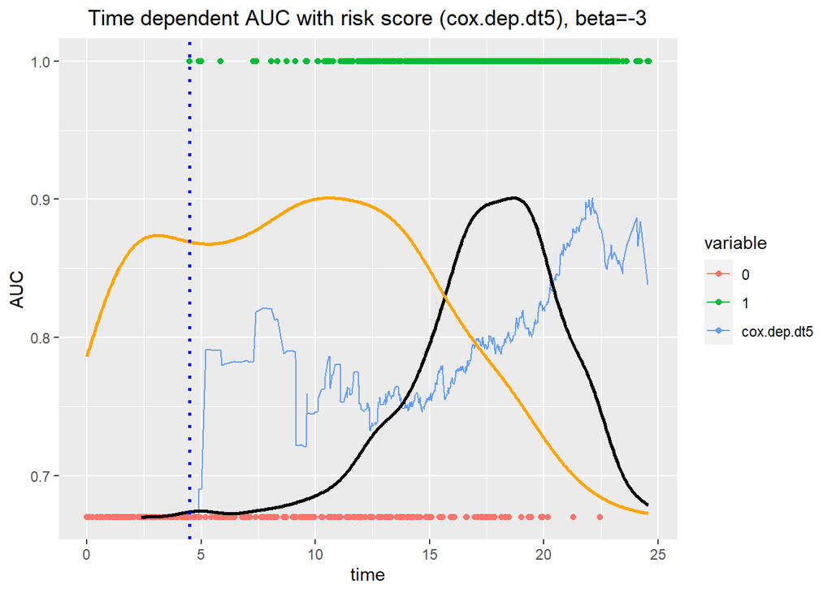

```r
dt5$censor1 <- ifelse(dt5$censor==1,
                    1,min(na.omit(ROC.risk.dep.dt5[["AUC"]])))
ggplot() +
  geom_line(data=res5, aes(x=time, y=value,
                            group=variable, color=variable)) +
  geom_point(data=dt5, aes(x=time, y=censor1, color=as.factor(censor))) +
  geom_line(data=data5_1, aes(x=time, y=density.adjusted),
            size=1, colour='black') +
  geom_line(data=data5_2, aes(x=time, y=density.adjusted),
            size=1, colour='orange') +
  scale_x_continuous(limits = c(0, max(dt5$time))) +
  geom_vline(xintercept = min(dt5$time[dt5$censor==1]),
             linetype="dotted", color = "blue", size=1) +
  ggtitle("Time dependent AUC with risk score (cox.dep.dt5), beta=-3") +
  xlab("time") + ylab("AUC") +
  theme(plot.title = element_text(hjust = 0.5))
```

#### Mean value of Time dependent AUC (cox.dep.dt5)

```r
mean(ROC.risk.dep.dt5[["AUC"]],na.rm=TRUE)
```

```
## [1] 0.7954335
```

#### simulation (repeat 100 times / time VS mean of AUC)

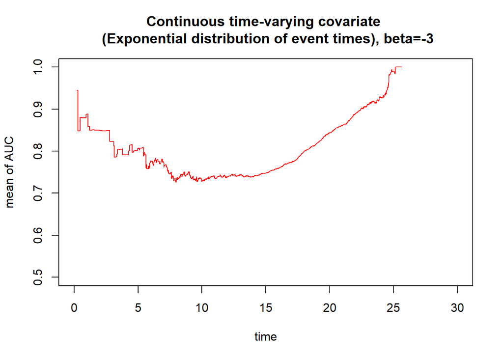

```r
con.AUC <- matrix(nrow=length(seq(0,30,0.01)),ncol=100)

for (i in 1:100) {

  lambda1 <- 0.003 # parameter for generate Y
  lambda2 <- 0.2/lambda1 # parameter for generate C
  beta0 <- -3 ; gamma0 <- 2 ; alpha0 <- 4 # true coefficients
  Y <- c() # real survival time
  C <- c() # censoring time
  t <- c() # observed survival time
  censor <- c() # censoring indicator
  X <- c() # time invariant covariate
  U1 <- c() # random variable from U(0,1) for generate Y
  U2 <- c() # random variable from U(0,1) for generate C

  # Generate simulation data
  set.seed(i)
  for (j in 1:200) {
    U1[j] <- runif(1)
    U2[j] <- runif(1)
    X[j] <- runif(1,min=0,max=1)
    Y[j] <- (1/gamma0*alpha0)*log(1-(gamma0*alpha0/lambda1/exp(beta0*X[j]))*log(U1[j]))
    C[j] <- (lambda2)*(1-U2[j])
    t[j] <- min(Y[j],C[j])
    censor[j] <- ifelse(Y[j]<=C[j],1,0)
  }
  dt5 <- data.frame(X=X, Y=Y, C=C, time=t, censor=censor)

  # Set Cox regression model
  cox.dep.dt5 <- coxph(Surv(time,censor) ~ X, data=dt5)
  summary(cox.dep.dt5)
  risk.dep.dt5 <- predict(object=cox.dep.dt5, newdata=dt5, type="risk") # risk score
  dt5$risk.dep.dt5 <- risk.dep.dt5
  ROC.risk.dep.dt5 <- timeROC(T=dt5$time,
                           delta=dt5$censor,marker=dt5$risk.dep.dt5,
                           cause=1,weighting="marginal",
                           times=seq(0,30,0.01))

  con.AUC[,i] <- ROC.risk.dep.dt5[["AUC"]]

  # print(i)

}

dat5 <- data.frame(time=seq(0,30,0.01), con.AUC=rowMeans(con.AUC, na.rm=TRUE))
plot(x=dat5$time, y=dat5$con.AUC, xlab="time", ylab="mean of AUC",
     main="Continuous time-varying covariate \n (Exponential distribution of event times), beta=-3", type="l", col="red", ylim=c(0.5,1))
```

## Example 2

## Generating simulation data

```r
lambda1 <- 0.003 # parameter for generate Y
lambda2 <- 0.2/lambda1 # parameter for generate C
beta0 <- 3 ; gamma0 <- 2 ; alpha0 <- 4 # true coefficients
Y <- c() # real survival time
C <- c() # censoring time
t <- c() # observed survival time
censor <- c() # censoring indicator
X <- c() # time invariant covariate
U1 <- c() # random variable from U(0,1) for generate Y
U2 <- c() # random variable from U(0,1) for generate C

for (i in 1:1000) {
  U1[i] <- runif(1)
  U2[i] <- runif(1)
  X[i] <- runif(1,min=0,max=1)
  Y[i] <- (1/gamma0*alpha0)*log(1-(gamma0*alpha0/lambda1/exp(beta0*X[i]))*log(U1[i]))
  C[i] <- (lambda2)*(1-U2[i])
  t[i] <- min(Y[i],C[i])
  censor[i] <- ifelse(Y[i]<=C[i],1,0)
}

mean(1-censor) # censoring rate
```

```
## [1] 0.162
```

```r
dt5 <- data.frame(X=X, Y=Y, C=C, time=t, censor=censor)
head(dt5,10)
```

```
##            X         Y         C      time censor
## 1  0.1542048 17.328656 28.019634 17.328656      1
## 2  0.9133426 11.764816 56.800946 11.764816      1
## 3  0.6490225 12.497465 30.502314 12.497465      1
## 4  0.2935051 15.303432 10.070637 10.070637      0
## 5  0.6469844 10.862118  8.457676  8.457676      0
## 6  0.3568592 13.478904 64.697770 13.478904      1
## 7  0.8048720  8.920961 46.703445  8.920961      1
## 8  0.3771634 10.796717 52.590988 10.796717      1
## 9  0.4164615 13.589106  6.828415  6.828415      0
## 10 0.1373967 11.521322 45.237351 11.521322      1
```

```r
min(dt5$time[dt5$censor==1])
```

```
## [1] 0.2653944
```

### Time dependent AUC

### True model

- model : $h(t,x,z(t))=h_{0}(t)exp[\beta x + \gamma z(t)]$
- $z(t)=\alpha t$
- $h_{0}(t)=\lambda$
- True coefficients : $\beta=3$, $\gamma=2$, $\alpha=4$

### Set Cox regression model

```r
cox.dep.dt5 <- coxph(Surv(time,censor) ~ X, data=dt5)
summary(cox.dep.dt5)
```

```
## Call:
## coxph(formula = Surv(time, censor) ~ X, data = dt5)
##
##   n= 1000, number of events= 838
##
##      coef exp(coef) se(coef)     z Pr(>|z|)
## X  2.7590   15.7842   0.1474 18.71   <2e-16 ***
## ---
## Signif. codes:  0 '***' 0.001 '**' 0.01 '*' 0.05 '.' 0.1 ' ' 1
##
##   exp(coef) exp(-coef) lower .95 upper .95
## X     15.78    0.06335     11.82     21.07
##
## Concordance= 0.692  (se = 0.009 )
## Likelihood ratio test= 369.9  on 1 df,   p=<2e-16
## Wald test            = 350.2  on 1 df,   p=<2e-16
## Score (logrank) test = 380.4  on 1 df,   p=<2e-16
```

```r
risk.dep.dt5 <- predict(object=cox.dep.dt5, newdata=dt5, type="risk") # risk score
dt5$risk.dep.dt5 <- risk.dep.dt5
ROC.risk.dep.dt5 <- timeROC(T=dt5$time,
                         delta=dt5$censor,marker=dt5$risk.dep.dt5,
                         cause=1,weighting="marginal",
                         times=dt5$time)
ROC.risk.dep.dt5
```

```
## Time-dependent-Roc curve estimated using IPCW  (n=1000, without competing risks).
##                      Cases Survivors Censored AUC (%)
## t=0.0517302192747593     0       999        1      NA
## t=8.50695348253445     131       749      120   71.36
## t=11.0446829141919     350       500      150   75.98
## t=13.2842449457372     591       250      159   81.68
## t=19.0686534314023     837         0      163      NA
##
## Method used for estimating IPCW:marginal
##
## Total computation time : 0.57  secs.
```

#### Make AUC data

```r
# uncensored
uncensored.density5 <- density(dt5$time[dt5$censor==1])
data5_1 <- data.frame(time=uncensored.density5[["x"]],
                    density=uncensored.density5[["y"]])
data5_1$density.adjusted <- (max(na.omit(ROC.risk.dep.dt5[["AUC"]]))-min(na.omit(ROC.risk.dep.dt5[["AUC"]])))*(uncensored.density5[["y"]]-min(uncensored.density5[["y"]]))/(max(uncensored.density5[["y"]])-min(uncensored.density5[["y"]]))+min(na.omit(ROC.risk.dep.dt5[["AUC"]]))

# censored
censored.density5 <- density(dt5$time[dt5$censor==0])
data5_2 <- data.frame(time=censored.density5[["x"]],
                    density=censored.density5[["y"]])
data5_2$density.adjusted <- (max(na.omit(ROC.risk.dep.dt5[["AUC"]]))-min(na.omit(ROC.risk.dep.dt5[["AUC"]])))*(censored.density5[["y"]]-min(censored.density5[["y"]]))/(max(censored.density5[["y"]])-min(censored.density5[["y"]]))+min(na.omit(ROC.risk.dep.dt5[["AUC"]]))

res5 <- data.frame(time=ROC.risk.dep.dt5[["times"]],
                    cox.dep.dt5=ROC.risk.dep.dt5[["AUC"]])
res5 <- melt(data = res5,
                   id.vars = "time",
                   measure.vars = c("cox.dep.dt5"))
```

#### Time dependent AUC plot with ggplot2 (cox.dep.dt5)

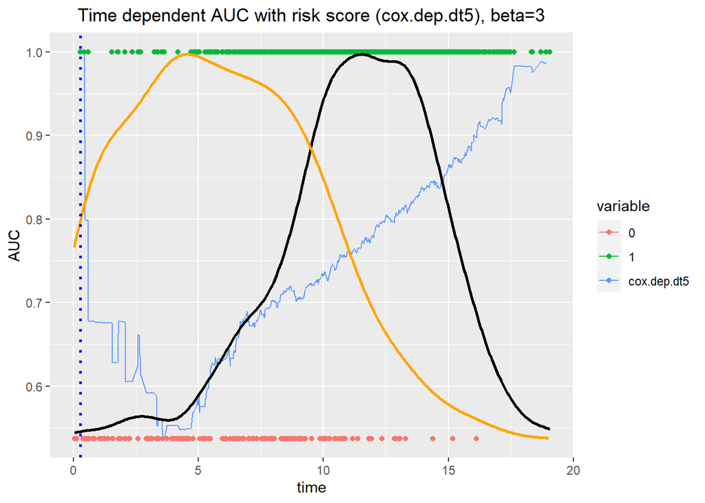

```r
dt5$censor1 <- ifelse(dt5$censor==1,
                    1,min(na.omit(ROC.risk.dep.dt5[["AUC"]])))
ggplot() +
  geom_line(data=res5, aes(x=time, y=value,
                            group=variable, color=variable)) +
  geom_point(data=dt5, aes(x=time, y=censor1, color=as.factor(censor))) +
  geom_line(data=data5_1, aes(x=time, y=density.adjusted),
            size=1, colour='black') +
  geom_line(data=data5_2, aes(x=time, y=density.adjusted),
            size=1, colour='orange') +
  scale_x_continuous(limits = c(0, max(dt5$time))) +
  geom_vline(xintercept = min(dt5$time[dt5$censor==1]),
             linetype="dotted", color = "blue", size=1) +
  ggtitle("Time dependent AUC with risk score (cox.dep.dt5), beta=3") +
  xlab("time") + ylab("AUC") +
  theme(plot.title = element_text(hjust = 0.5))
```

#### Mean value of Time dependent AUC (cox.dep.dt5)

```r
mean(ROC.risk.dep.dt5[["AUC"]],na.rm=TRUE)
```

```
## [1] 0.7561979
```

#### simulation (repeat 100 times / time VS mean of AUC)

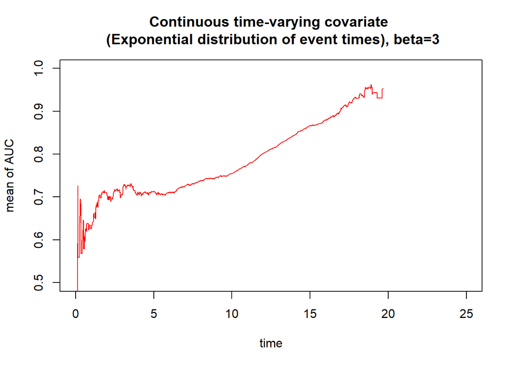

```r
con.AUC <- matrix(nrow=length(seq(0,25,0.01)),ncol=100)

for (i in 1:100) {

  lambda1 <- 0.003 # parameter for generate Y
  lambda2 <- 0.2/lambda1 # parameter for generate C
  beta0 <- 3 ; gamma0 <- 2 ; alpha0 <- 4 # true coefficients
  Y <- c() # real survival time
  C <- c() # censoring time
  t <- c() # observed survival time
  censor <- c() # censoring indicator
  X <- c() # time invariant covariate
  U1 <- c() # random variable from U(0,1) for generate Y
  U2 <- c() # random variable from U(0,1) for generate C

  # Generate simulation data
  set.seed(i)
  for (j in 1:200) {
    U1[j] <- runif(1)
    U2[j] <- runif(1)
    X[j] <- runif(1,min=0,max=1)
    Y[j] <- (1/gamma0*alpha0)*log(1-(gamma0*alpha0/lambda1/exp(beta0*X[j]))*log(U1[j]))
    C[j] <- (lambda2)*(1-U2[j])
    t[j] <- min(Y[j],C[j])
    censor[j] <- ifelse(Y[j]<=C[j],1,0)
  }
  dt5 <- data.frame(X=X, Y=Y, C=C, time=t, censor=censor)

  # Set Cox regression model
  cox.dep.dt5 <- coxph(Surv(time,censor) ~ X, data=dt5)
  summary(cox.dep.dt5)
  risk.dep.dt5 <- predict(object=cox.dep.dt5, newdata=dt5, type="risk") # risk score
  dt5$risk.dep.dt5 <- risk.dep.dt5
  ROC.risk.dep.dt5 <- timeROC(T=dt5$time,
                           delta=dt5$censor,marker=dt5$risk.dep.dt5,
                           cause=1,weighting="marginal",
                           times=seq(0,25,0.01))

  con.AUC[,i] <- ROC.risk.dep.dt5[["AUC"]]

  # print(i)

}

dat5 <- data.frame(time=seq(0,25,0.01), con.AUC=rowMeans(con.AUC, na.rm=TRUE))
plot(x=dat5$time, y=dat5$con.AUC, xlab="time", ylab="mean of AUC",
     main="Continuous time-varying covariate \n (Exponential distribution of event times), beta=3", type="l", col="red", ylim=c(0.5,1))
```

## Case 2) Dichotomous time-varying covariate: exponential distribution of event times

- $Y$ : real survival time
- $C$ : censoring time
- model : $h(t,x,z(t))=h_{0}(t)exp(\beta x + \gamma z(t))$
- $Y$ : Assume $z(t)=\begin{cases} 0, & \mbox{if } t<t_{0} \\ 1, & \mbox{if } t \geq t_{0} \end{cases}$
- $h_{0}(t)=\lambda$
- If $t<t_{0}$, then $H(t,x,z(t))=\int_{0}^{t}h_{0}(s)exp(\gamma z(s) + \beta x)ds=\int_{0}^{t}\lambda exp(\beta x)ds=\lambda exp(\beta x)t$
- If $t \geq t_{0}$, then $H(t,x,z(t))=\int_{0}^{t}h_{0}(s)exp(\gamma z(s) + \beta x)ds=\int_{0}^{t} \lambda exp(\gamma z(s) + \beta x)ds=\lambda exp(\beta x) \int_{0}^{t}exp(\gamma z(s))ds=\lambda exp(\beta x) [ \int_{0}^{t_{0}}ds+\int_{t_{0}}^{t}exp(\gamma)ds ]=\lambda exp(\beta x)[t_{0}+exp(\gamma)t - exp(\gamma) t_{0}]$
- Hence, $H^{-1}(t,x,z(t))=\begin{cases} \frac {t}{\lambda exp(\beta x)}, & \mbox{if } t < \lambda exp(\beta x)t_{0} \\ \frac {t - \lambda exp(\beta x)t_{0} + \lambda exp(\beta x + \gamma)t_{0}}{\lambda exp(\beta x + \gamma)}, & \mbox{if } t \geq \lambda exp(\beta x)t_{0} \end{cases}$
- Therefore, $T=\begin{cases} \frac {-log(U)}{\lambda exp(\beta x)}, & \mbox{if } -log(U) < \lambda exp(\beta x)t_{0} \\ \frac {-log(U) - \lambda exp(\beta x)t_{0} + \lambda exp(\beta x + \gamma)t_{0}}{\lambda exp(\beta x + \gamma)}, & \mbox{if } -log(U) \geq \lambda exp(\beta x)t_{0} \end{cases}$ when $U \sim U(0,1)$
- $C$ : $f_{C0}(t)=\frac {1}{\lambda}, 0<t<\lambda$ -> $S_{C0}(t)=1-\frac {t}{\lambda}$ -> $h_{C0}(t)=\frac {1}{\lambda -t}$
- By Inverse Transform Sampling and non-informative censoring, suppose that $U_{1}, U_{2} \overset{i.i.d}{\sim}\ U(0,1)$, then we can generate real survival time $Y$ and censoring time $C$ like this.
- $\therefore Y=\begin{cases} \frac {-log(U_{1})}{\lambda exp(\beta x)}, & \mbox{if } -log(U_{1}) < \lambda exp(\beta x)t_{0} \\ \frac {-log(U_{1}) - \lambda exp(\beta x)t_{0} + \lambda exp(\beta x + \gamma)t_{0}}{\lambda exp(\beta x + \gamma)}, & \mbox{if } -log(U_{1}) \geq \lambda exp(\beta x)t_{0} \end{cases}$
- $\therefore C=\lambda_{2}(1-U_{2})$

## Example 1

## Generating simulation data

```r
lambda1 <- 0.003 # parameter for generate Y
lambda2 <- 2.5/lambda1 # parameter for generate C
beta0 <- -3 ; gamma0 <- 2 # true coefficients
t0 <- 30 # denote the time at which the time-varying covariate changes from unexposed (Z(t) = 0) to exposed (Z(t) = 1)
Y <- c() # real survival time
C <- c() # censoring time
t <- c() # observed survival time
censor <- c() # censoring indicator
X <- c() # time invariant covariate
U1 <- c() # random variable from U(0,1) for generate Y
U2 <- c() # random variable from U(0,1) for generate C

for (i in 1:1000) {
  U1[i] <- runif(1)
  U2[i] <- runif(1)
  X[i] <- runif(1,min=0,max=1)
  Y[i] <- ifelse(-log(U1[i])<lambda1*exp(beta0*X[i])*t0, -log(U1[i])/lambda1/exp(beta0*X[i]), (-log(U1[i])-lambda1*exp(beta0*X[i])*t0+lambda1*exp(beta0*X[i]+gamma0)*t0)/lambda1/exp(beta0*X[i]+gamma0))
  C[i] <- (lambda2)*(1-U2[i])
  t[i] <- min(Y[i],C[i])
  censor[i] <- ifelse(Y[i]<=C[i],1,0)
}

mean(1-censor) # censoring rate
```

```
## [1] 0.326
```

```r
dt6 <- data.frame(X=X, Y=Y, C=C, time=t, censor=censor)
head(dt6,10)
```

```
##            X          Y         C      time censor
## 1  0.1542048  273.07693 350.24542 273.07693      1
## 2  0.9133426 1477.26195 710.01182 710.01182      0
## 3  0.6490225  454.95460 381.27892 381.27892      0
## 4  0.2935051  232.96293 125.88296 125.88296      0
## 5  0.6469844  212.57146 105.72095 105.72095      0
## 6  0.3568592  147.44809 808.72212 147.44809      1
## 7  0.8048720  206.96701 583.79306 206.96701      1
## 8  0.3771634   61.71902 657.38735  61.71902      1
## 9  0.4164615  209.53995  85.35519  85.35519      0
## 10 0.1373967   38.15226 565.46689  38.15226      1
```

```r
min(dt6$time[dt6$censor==1])
```

```
## [1] 0.5859794
```

### Time dependent AUC

### True model

- model : $h(t,x,z(t))=h_{0}(t)exp[\beta x + \gamma z(t)]$
- $z(t)=\begin{cases} 0, & \mbox{if } t<t_{0} \\ 1, & \mbox{if } t \geq t_{0} \end{cases}$
- $h_{0}(t)=\lambda$
- True coefficients : $\beta=-3$, $\gamma=2$

### Set Cox regression model

```r
cox.dep.dt6 <- coxph(Surv(time,censor) ~ X, data=dt6)
summary(cox.dep.dt6)
```

```
## Call:
## coxph(formula = Surv(time, censor) ~ X, data = dt6)
##
##   n= 1000, number of events= 674
##
##      coef exp(coef) se(coef)      z Pr(>|z|)
## X -3.1820    0.0415   0.1580 -20.14   <2e-16 ***
## ---
## Signif. codes:  0 '***' 0.001 '**' 0.01 '*' 0.05 '.' 0.1 ' ' 1
##
##   exp(coef) exp(-coef) lower .95 upper .95
## X    0.0415      24.09   0.03045   0.05657
##
## Concordance= 0.73  (se = 0.01 )
## Likelihood ratio test= 432.8  on 1 df,   p=<2e-16
## Wald test            = 405.5  on 1 df,   p=<2e-16
## Score (logrank) test = 449.3  on 1 df,   p=<2e-16
```

```r
risk.dep.dt6 <- predict(object=cox.dep.dt6, newdata=dt6, type="risk") # risk score
dt6$risk.dep.dt6 <- risk.dep.dt6
ROC.risk.dep.dt6 <- timeROC(T=dt6$time,
                         delta=dt6$censor,marker=dt6$risk.dep.dt6,
                         cause=1,weighting="marginal",
                         times=dt6$time)
ROC.risk.dep.dt6
```

```
## Time-dependent-Roc curve estimated using IPCW  (n=1000, without competing risks).
##                    Cases Survivors Censored AUC (%)
## t=0.58597937147662     0       999        1      NA
## t=57.6523668490446   188       749       63   78.50
## t=120.921584849107   381       500      119   78.19
## t=257.864298318053   566       250      184   84.81
## t=825.777832457485   674         0      326      NA
##
## Method used for estimating IPCW:marginal
##
## Total computation time : 0.67  secs.
```

#### Make AUC data

```r
# uncensored
uncensored.density6 <- density(dt6$time[dt6$censor==1])
data6_1 <- data.frame(time=uncensored.density6[["x"]],
                    density=uncensored.density6[["y"]])
data6_1$density.adjusted <- (max(na.omit(ROC.risk.dep.dt6[["AUC"]]))-min(na.omit(ROC.risk.dep.dt6[["AUC"]])))*(uncensored.density6[["y"]]-min(uncensored.density6[["y"]]))/(max(uncensored.density6[["y"]])-min(uncensored.density6[["y"]]))+min(na.omit(ROC.risk.dep.dt6[["AUC"]]))

# censored
censored.density6 <- density(dt6$time[dt6$censor==0])
data6_2 <- data.frame(time=censored.density6[["x"]],
                    density=censored.density6[["y"]])
data6_2$density.adjusted <- (max(na.omit(ROC.risk.dep.dt6[["AUC"]]))-min(na.omit(ROC.risk.dep.dt6[["AUC"]])))*(censored.density6[["y"]]-min(censored.density6[["y"]]))/(max(censored.density6[["y"]])-min(censored.density6[["y"]]))+min(na.omit(ROC.risk.dep.dt6[["AUC"]]))

res6 <- data.frame(time=ROC.risk.dep.dt6[["times"]],
                    cox.dep.dt6=ROC.risk.dep.dt6[["AUC"]])
res6 <- melt(data = res6,
                   id.vars = "time",
                   measure.vars = c("cox.dep.dt6"))
```

#### Time dependent AUC plot with ggplot2 (cox.dep.dt6)

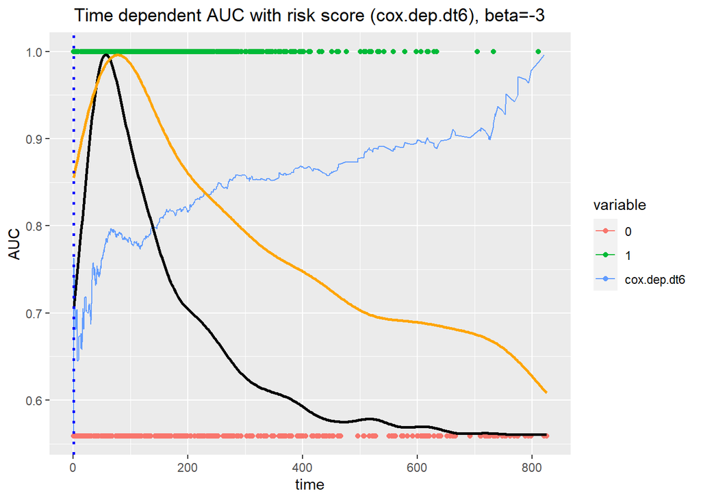

```r
dt6$censor1 <- ifelse(dt6$censor==1,
                    1,min(na.omit(ROC.risk.dep.dt6[["AUC"]])))
ggplot() +
  geom_line(data=res6, aes(x=time, y=value,
                            group=variable, color=variable)) +
  geom_point(data=dt6, aes(x=time, y=censor1, color=as.factor(censor))) +
  geom_line(data=data6_1, aes(x=time, y=density.adjusted),
            size=1, colour='black') +
  geom_line(data=data6_2, aes(x=time, y=density.adjusted),
            size=1, colour='orange') +
  scale_x_continuous(limits = c(0, max(dt6$time))) +
  geom_vline(xintercept = min(dt6$time[dt6$censor==1]),
             linetype="dotted", color = "blue", size=1) +
  ggtitle("Time dependent AUC with risk score (cox.dep.dt6), beta=-3") +
  xlab("time") + ylab("AUC") +
  theme(plot.title = element_text(hjust = 0.5))
```

#### Mean value of Time dependent AUC (cox.dep.dt6)

```r
mean(ROC.risk.dep.dt6[["AUC"]],na.rm=TRUE)
```

```
## [1] 0.8018151
```

#### simulation (repeat 100 times / time VS mean of AUC)

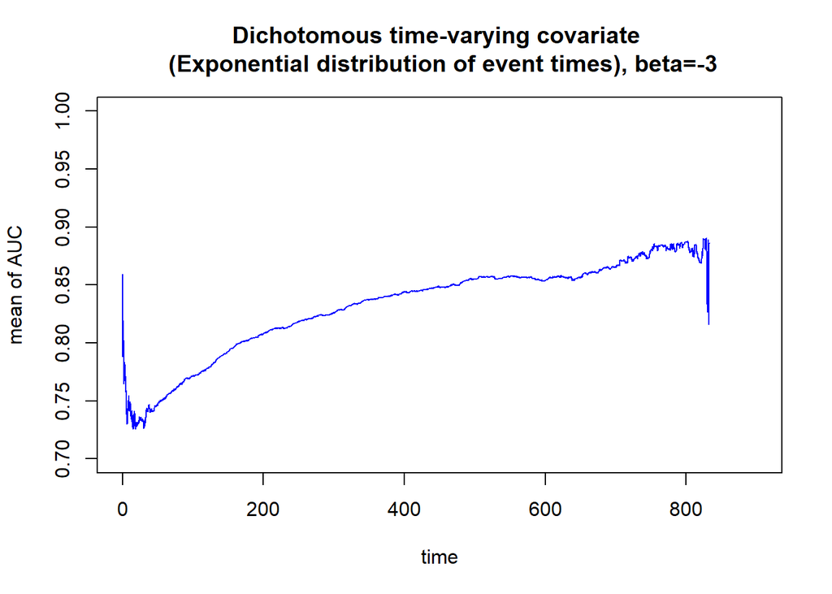

```r
din.AUC <- matrix(nrow=length(seq(0,900,0.1)),ncol=100)

for (i in 1:100) {

  lambda1 <- 0.003 # parameter for generate Y
  lambda2 <- 2.5/lambda1 # parameter for generate C
  beta0 <- -3 ; gamma0 <- 2 # true coefficients
  t0 <- 30 # denote the time at which the time-varying covariate changes from unexposed (Z(t) = 0) to exposed (Z(t) = 1)
  Y <- c() # real survival time
  C <- c() # censoring time
  t <- c() # observed survival time
  censor <- c() # censoring indicator
  X <- c() # time invariant covariate
  U1 <- c() # random variable from U(0,1) for generate Y
  U2 <- c() # random variable from U(0,1) for generate C

  # Generate simulation data
  set.seed(i)
  for (j in 1:200) {
    U1[j] <- runif(1)
    U2[j] <- runif(1)
    X[j] <- runif(1,min=0,max=1)
    Y[j] <- ifelse(-log(U1[j])<lambda1*exp(beta0*X[j])*t0, -log(U1[j])/lambda1/exp(beta0*X[j]), (-log(U1[j])-lambda1*exp(beta0*X[j])*t0+lambda1*exp(beta0*X[j]+gamma0)*t0)/lambda1/exp(beta0*X[j]+gamma0))
    C[j] <- (lambda2)*(1-U2[j])
    t[j] <- min(Y[j],C[j])
    censor[j] <- ifelse(Y[j]<=C[j],1,0)
  }
  dt6 <- data.frame(X=X, Y=Y, C=C, time=t, censor=censor)

  # Set Cox regression model
  cox.dep.dt6 <- coxph(Surv(time,censor) ~ X, data=dt6)
  summary(cox.dep.dt6)
  risk.dep.dt6 <- predict(object=cox.dep.dt6, newdata=dt6, type="risk") # risk score
  dt6$risk.dep.dt6 <- risk.dep.dt6
  ROC.risk.dep.dt6 <- timeROC(T=dt6$time,
                           delta=dt6$censor,marker=dt6$risk.dep.dt6,
                           cause=1,weighting="marginal",
                           times=seq(0,900,0.1))

  din.AUC[,i] <- ROC.risk.dep.dt6[["AUC"]]

  # print(i)

}

dat6 <- data.frame(time=seq(0,900,0.1), din.AUC=rowMeans(din.AUC, na.rm=TRUE))
plot(x=dat6$time, y=dat6$din.AUC, xlab="time", ylab="mean of AUC",
     main="Dichotomous time-varying covariate \n (Exponential distribution of event times), beta=-3", type="l", col="blue", ylim=c(0.7,1))
```

## Example 2

## Generating simulation data

```r
lambda1 <- 0.003 # parameter for generate Y
lambda2 <- 2.5/lambda1 # parameter for generate C
beta0 <- 3 ; gamma0 <- 2 # true coefficients
t0 <- 30 # denote the time at which the time-varying covariate changes from unexposed (Z(t) = 0) to exposed (Z(t) = 1)
Y <- c() # real survival time
C <- c() # censoring time
t <- c() # observed survival time
censor <- c() # censoring indicator
X <- c() # time invariant covariate
U1 <- c() # random variable from U(0,1) for generate Y
U2 <- c() # random variable from U(0,1) for generate C

for (i in 1:1000) {
  U1[i] <- runif(1)
  U2[i] <- runif(1)
  X[i] <- runif(1,min=0,max=1)
  Y[i] <- ifelse(-log(U1[i])<lambda1*exp(beta0*X[i])*t0, -log(U1[i])/lambda1/exp(beta0*X[i]), (-log(U1[i])-lambda1*exp(beta0*X[i])*t0+lambda1*exp(beta0*X[i]+gamma0)*t0)/lambda1/exp(beta0*X[i]+gamma0))
  C[i] <- (lambda2)*(1-U2[i])
  t[i] <- min(Y[i],C[i])
  censor[i] <- ifelse(Y[i]<=C[i],1,0)
}

mean(1-censor) # censoring rate
```

```
## [1] 0.035
```

```r
dt6 <- data.frame(X=X, Y=Y, C=C, time=t, censor=censor)
head(dt6,10)
```

```
##            X         Y         C      time censor
## 1  0.1542048 123.91508 350.24542 123.91508      1
## 2  0.9133426  31.99064 710.01182  31.99064      1
## 3  0.6490225  34.67510 381.27892  34.67510      1
## 4  0.2935051  61.52050 125.88296  61.52050      1
## 5  0.6469844  28.42388 105.72095  28.42388      1
## 6  0.3568592  40.21946 808.72212  40.21946      1
## 7  0.8048720  10.69113 583.79306  10.69113      1
## 8  0.3771634  27.50541 657.38735  27.50541      1
## 9  0.4164615  41.02932  85.35519  41.02932      1
## 10 0.1373967  31.29513 565.46689  31.29513      1
```

```r
min(dt6$time[dt6$censor==1])
```

```
## [1] 0.01773802
```

### Time dependent AUC

### True model

- model : $h(t,x,z(t))=h_{0}(t)exp[\beta x + \gamma z(t)]$
- $z(t)=\begin{cases} 0, & \mbox{if } t<t_{0} \\ 1, & \mbox{if } t \geq t_{0} \end{cases}$
- $h_{0}(t)=\lambda$
- True coefficients : $\beta=3$, $\gamma=2$

### Set Cox regression model

```r
cox.dep.dt6 <- coxph(Surv(time,censor) ~ X, data=dt6)
summary(cox.dep.dt6)
```

```
## Call:
## coxph(formula = Surv(time, censor) ~ X, data = dt6)
##
##   n= 1000, number of events= 965
##
##      coef exp(coef) se(coef)     z Pr(>|z|)
## X  2.7915   16.3058   0.1389 20.09   <2e-16 ***
## ---
## Signif. codes:  0 '***' 0.001 '**' 0.01 '*' 0.05 '.' 0.1 ' ' 1
##
##   exp(coef) exp(-coef) lower .95 upper .95
## X     16.31    0.06133     12.42     21.41
##
## Concordance= 0.692  (se = 0.009 )
## Likelihood ratio test= 425.4  on 1 df,   p=<2e-16
## Wald test            = 403.6  on 1 df,   p=<2e-16
## Score (logrank) test = 437.8  on 1 df,   p=<2e-16
```

```r
risk.dep.dt6 <- predict(object=cox.dep.dt6, newdata=dt6, type="risk") # risk score
dt6$risk.dep.dt6 <- risk.dep.dt6
ROC.risk.dep.dt6 <- timeROC(T=dt6$time,
                         delta=dt6$censor,marker=dt6$risk.dep.dt6,
                         cause=1,weighting="marginal",
                         times=dt6$time)
ROC.risk.dep.dt6
```

```
## Time-dependent-Roc curve estimated using IPCW  (n=1000, without competing risks).
##                      Cases Survivors Censored AUC (%)
## t=0.0177380223041212     0       999        1      NA
## t=15.6465790340145     232       749       19   72.33
## t=31.5794295484611     471       500       29   76.70
## t=40.4770968399253     719       250       31   81.81
## t=259.821036551796     964         0       36      NA
##
## Method used for estimating IPCW:marginal
##
## Total computation time : 0.44  secs.
```

#### Make AUC data

```r
# uncensored
uncensored.density6 <- density(dt6$time[dt6$censor==1])
data6_1 <- data.frame(time=uncensored.density6[["x"]],
                    density=uncensored.density6[["y"]])
data6_1$density.adjusted <- (max(na.omit(ROC.risk.dep.dt6[["AUC"]]))-min(na.omit(ROC.risk.dep.dt6[["AUC"]])))*(uncensored.density6[["y"]]-min(uncensored.density6[["y"]]))/(max(uncensored.density6[["y"]])-min(uncensored.density6[["y"]]))+min(na.omit(ROC.risk.dep.dt6[["AUC"]]))

# censored
censored.density6 <- density(dt6$time[dt6$censor==0])
data6_2 <- data.frame(time=censored.density6[["x"]],
                    density=censored.density6[["y"]])
data6_2$density.adjusted <- (max(na.omit(ROC.risk.dep.dt6[["AUC"]]))-min(na.omit(ROC.risk.dep.dt6[["AUC"]])))*(censored.density6[["y"]]-min(censored.density6[["y"]]))/(max(censored.density6[["y"]])-min(censored.density6[["y"]]))+min(na.omit(ROC.risk.dep.dt6[["AUC"]]))

res6 <- data.frame(time=ROC.risk.dep.dt6[["times"]],
                    cox.dep.dt6=ROC.risk.dep.dt6[["AUC"]])
res6 <- melt(data = res6,
                   id.vars = "time",
                   measure.vars = c("cox.dep.dt6"))
```

#### Time dependent AUC plot with ggplot2 (cox.dep.dt6)

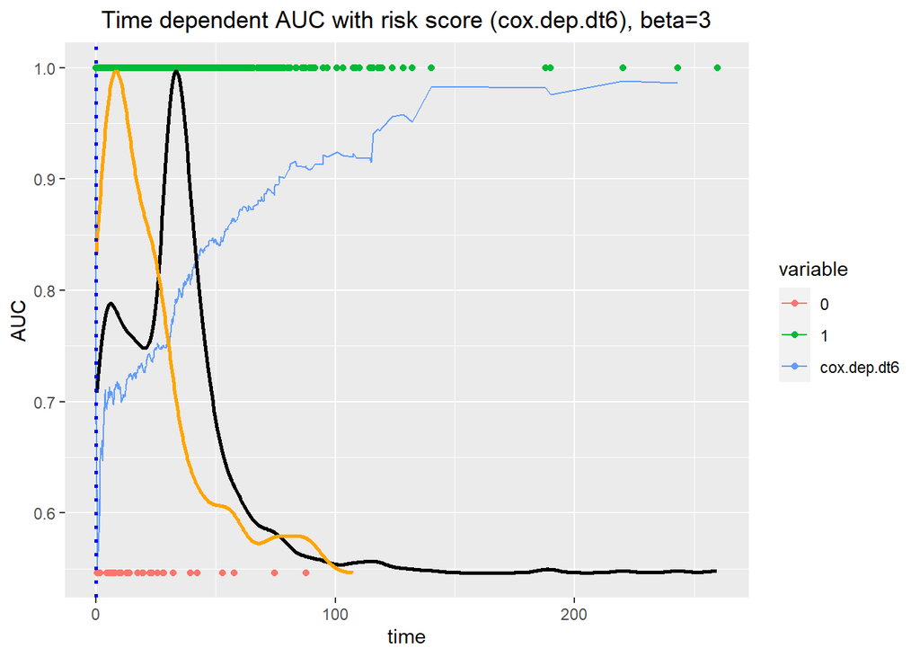

```r
dt6$censor1 <- ifelse(dt6$censor==1,
                    1,min(na.omit(ROC.risk.dep.dt6[["AUC"]])))
ggplot() +
  geom_line(data=res6, aes(x=time, y=value,
                            group=variable, color=variable)) +
  geom_point(data=dt6, aes(x=time, y=censor1, color=as.factor(censor))) +
  geom_line(data=data6_1, aes(x=time, y=density.adjusted),
            size=1, colour='black') +
  geom_line(data=data6_2, aes(x=time, y=density.adjusted),
            size=1, colour='orange') +
  scale_x_continuous(limits = c(0, max(dt6$time))) +
  geom_vline(xintercept = min(dt6$time[dt6$censor==1]),
             linetype="dotted", color = "blue", size=1) +
  ggtitle("Time dependent AUC with risk score (cox.dep.dt6), beta=3") +
  xlab("time") + ylab("AUC") +
  theme(plot.title = element_text(hjust = 0.5))
```

#### Mean value of Time dependent AUC (cox.dep.dt6)

```r
mean(ROC.risk.dep.dt6[["AUC"]],na.rm=TRUE)
```

```
## [1] 0.773049
```

#### simulation (repeat 100 times / time VS mean of AUC)

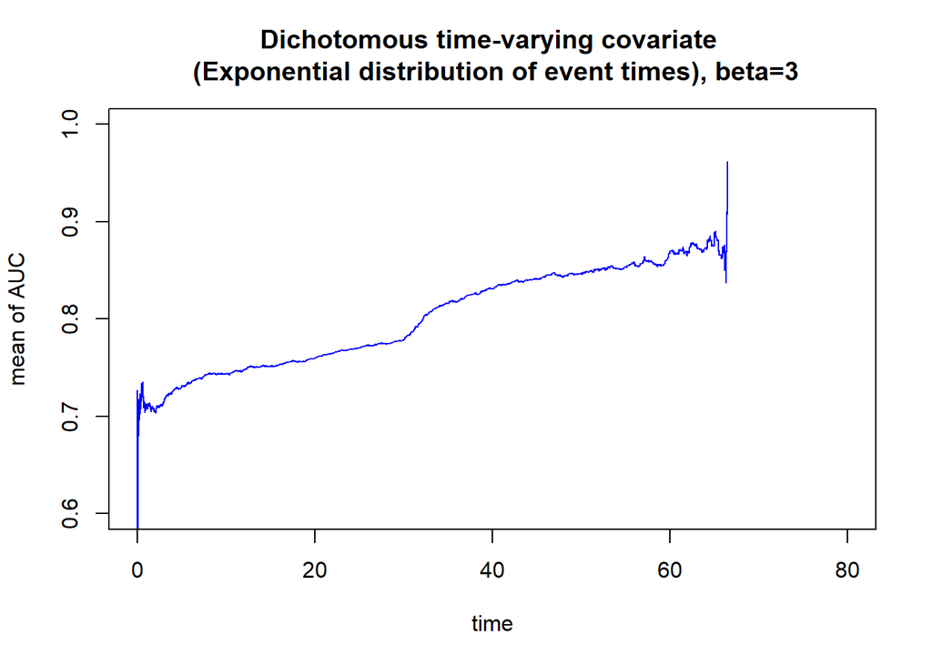

```r
din.AUC <- matrix(nrow=length(seq(0,80,0.01)),ncol=100)

for (i in 1:100) {

  lambda1 <- 0.003 # parameter for generate Y
  lambda2 <- 0.2/lambda1 # parameter for generate C
  beta0 <- 3 ; gamma0 <- 2 # true coefficients
  t0 <- 30 # denote the time at which the time-varying covariate changes from unexposed (Z(t) = 0) to exposed (Z(t) = 1)
  Y <- c() # real survival time
  C <- c() # censoring time
  t <- c() # observed survival time
  censor <- c() # censoring indicator
  X <- c() # time invariant covariate
  U1 <- c() # random variable from U(0,1) for generate Y
  U2 <- c() # random variable from U(0,1) for generate C

  # Generate simulation data
  set.seed(i)
  for (j in 1:200) {
    U1[j] <- runif(1)
    U2[j] <- runif(1)
    X[j] <- runif(1,min=0,max=1)
    Y[j] <- ifelse(-log(U1[j])<lambda1*exp(beta0*X[j])*t0, -log(U1[j])/lambda1/exp(beta0*X[j]), (-log(U1[j])-lambda1*exp(beta0*X[j])*t0+lambda1*exp(beta0*X[j]+gamma0)*t0)/lambda1/exp(beta0*X[j]+gamma0))
    C[j] <- (lambda2)*(1-U2[j])
    t[j] <- min(Y[j],C[j])
    censor[j] <- ifelse(Y[j]<=C[j],1,0)
  }
  dt6 <- data.frame(X=X, Y=Y, C=C, time=t, censor=censor)

  # Set Cox regression model
  cox.dep.dt6 <- coxph(Surv(time,censor) ~ X, data=dt6)
  summary(cox.dep.dt6)
  risk.dep.dt6 <- predict(object=cox.dep.dt6, newdata=dt6, type="risk") # risk score
  dt6$risk.dep.dt6 <- risk.dep.dt6
  ROC.risk.dep.dt6 <- timeROC(T=dt6$time,
                           delta=dt6$censor,marker=dt6$risk.dep.dt6,
                           cause=1,weighting="marginal",
                           times=seq(0,80,0.01))

  din.AUC[,i] <- ROC.risk.dep.dt6[["AUC"]]

  # print(i)

}

dat6 <- data.frame(time=seq(0,80,0.01), din.AUC=rowMeans(din.AUC, na.rm=TRUE))
plot(x=dat6$time, y=dat6$din.AUC, xlab="time", ylab="mean of AUC",
     main="Dichotomous time-varying covariate \n (Exponential distribution of event times), beta=3", type="l", col="blue", ylim=c(0.6,1))
```

## Case 3) Continuous time-varying covariate: exponential distribution of event times

- $Y$ : real survival time
- $C$ : censoring time
- model : $h(t,x,m,z(t))=h_{0}(t)exp(\beta x + \gamma mz(t))$
- $x$ : independent variable, $m$ : interaction with time dependent term
- $Y$ : Assume $z(t)=\alpha t$, $\alpha > 0$
- $h_{0}(t)=\lambda$
- $h(t,x,m,z(t))=\lambda exp(\beta x + \gamma m \alpha t)=-\frac{d}{dt} log[S(t,x,m,z(t))]$
- $log[S(t,x,m,z(t))]=-\int_{0}^{t}\lambda exp(\beta x + \gamma m \alpha s)ds=-\frac{\lambda exp(\beta x)}{\gamma m \alpha} [exp(\gamma m \alpha t)-1]$
- $S(t,x,m,z(t))=exp[-\frac{\lambda exp(\beta x)}{\gamma m \alpha} [exp(\gamma m \alpha t)-1]]$
- $F(t,x,m,z(t))=1-exp[-\frac{\lambda exp(\beta x)}{\gamma m \alpha} [exp(\gamma m \alpha t)-1]]$
- $F^{-1}(t,x,m,z(t))=\frac {1}{\gamma m \alpha} log[1-\frac {\gamma m \alpha}{\lambda exp(\beta x)} log(1-t)]$
- $C$ : $f_{C0}(t)=\frac {1}{\lambda}, 0<t<\lambda$ -> $S_{C0}(t)=1-\frac {t}{\lambda}$ -> $h_{C0}(t)=\frac {1}{\lambda -t}$
- By Inverse Transform Sampling and non-informative censoring, suppose that $U_{1}, U_{2} \overset{i.i.d}{\sim}\ U(0,1)$, then we can generate real survival time $Y$ and censoring time $C$ like this.
- $\therefore Y=\frac {1}{\gamma m \alpha} log[1-\frac {\gamma m \alpha}{\lambda_{1} exp(\beta x)} log(U_{1})]$
- $\therefore C=\lambda_{2}(1-U_{2})$

## Example 1

## Generating simulation data

```r
lambda1 <- 0.01 # parameter for generate Y
lambda2 <- 0.2/lambda1 # parameter for generate C
beta0 <- -3 ; gamma0 <- 1 ; alpha0 <- 2 # true coefficients
Y <- c() # real survival time
C <- c() # censoring time
t <- c() # observed survival time
censor <- c() # censoring indicator
X <- c() # time invariant covariate : N(0,1^2)
M <- c() # interaction with time dependent term : U(0,1)
U1 <- c() # random variable from U(0,1) for generate Y
U2 <- c() # random variable from U(0,1) for generate C

for (i in 1:1000) {
  U1[i] <- runif(1)
  U2[i] <- runif(1)
  X[i] <- runif(1,min=0,max=1)
  M[i] <- runif(1,min=0,max=1)
  Y[i] <- (1/gamma0*M[i]*alpha0)*log(1-(gamma0*M[i]*alpha0/lambda1/exp(beta0*X[i]))*log(U1[i]))
  C[i] <- (lambda2)*(1-U2[i])
  t[i] <- min(Y[i],C[i])
  censor[i] <- ifelse(Y[i]<=C[i],1,0)
}

mean(1-censor) # censoring rate
```

```
## [1] 0.27
```

```r
dt7 <- data.frame(X=X, Y=Y, C=C, M=M, time=t, censor=censor)
head(dt7,10)
```

```
##            X         Y         C         M     time censor
## 1  0.1542048  1.234941  8.405890 0.1252705 1.234941      1
## 2  0.2574304  6.627452  1.733147 0.5424653 1.733147      0
## 3  0.8489404  3.395089 17.016113 0.2935051 3.395089      1
## 4  0.6469844  4.605732  2.537303 0.3971834 2.537303      0
## 5  0.6985447  4.460472 12.862817 0.2994483 4.460472      1
## 6  0.2111352  2.610741  4.514418 0.3771634 2.610741      1
## 7  0.4164615 10.906843  2.048525 0.8358840 2.048525      0
## 8  0.6177129  9.302696 17.252066 0.6754165 9.302696      1
## 9  0.3303264  1.086240 16.275861 0.1218200 1.086240      1
## 10 0.7825414  6.524232  1.343067 0.4517651 1.343067      0
```

```r
min(dt7$time[dt7$censor==1])
```

```
## [1] 0.001828937
```

### Time dependent AUC

### True model

- model : $h(t,x,m,z(t))=h_{0}(t)exp[\beta x + \gamma m z(t)]$
- $z(t)=\alpha t$
- $h_{0}(t)=\lambda$
- True coefficients : $\beta=-3$, $\gamma=1$, $\alpha=2$
- https://stat.ethz.ch/R-manual/R-devel/library/mgcv/html/coxph.html

### Set Cox regression model

```r
cox.dep.dt7 <- gam(time ~ X + s(time,by=M), weights=censor, data=dt7, family=cox.ph)
summary(cox.dep.dt7)
```

```
##
## Family: Cox PH
## Link function: identity
##
## Formula:
## time ~ X + s(time, by = M)
##
## Parametric coefficients:
##   Estimate Std. Error z value Pr(>|z|)
## X  -1.9983     0.1485  -13.46   <2e-16 ***
## ---
## Signif. codes:  0 '***' 0.001 '**' 0.01 '*' 0.05 '.' 0.1 ' ' 1
##
## Approximate significance of smooth terms:
##             edf Ref.df Chi.sq p-value
## s(time):M 8.621   9.44  858.2  <2e-16 ***
## ---
## Signif. codes:  0 '***' 0.001 '**' 0.01 '*' 0.05 '.' 0.1 ' ' 1
##
## Deviance explained = 18.2%
## -REML = 3134.3  Scale est. = 1         n = 1000
```

```r
risk.dep.dt7 <- predict(object=cox.dep.dt7, newdata=dt7, type="link") # linear predictor (risk score)
dt7$risk.dep.dt7 <- risk.dep.dt7
ROC.risk.dep.dt7 <- timeROC(T=dt7$time,
                         delta=dt7$censor,marker=dt7$risk.dep.dt7,
                         cause=1,weighting="marginal",
                         times=dt7$time)
ROC.risk.dep.dt7
```

```
## Time-dependent-Roc curve estimated using IPCW  (n=1000, without competing risks).
##                       Cases Survivors Censored AUC (%)
## t=0.00182893731823102     0       999        1      NA
## t=1.51680930983275      168       749       83   99.35
## t=3.42647940812906      348       500      152   99.31
## t=6.80570872855254      528       250      222   99.10
## t=15.8960973192006      730         0      270      NA
##
## Method used for estimating IPCW:marginal
##
## Total computation time : 0.34  secs.
```

#### Make AUC data

```r
# uncensored
uncensored.density7 <- density(dt7$time[dt7$censor==1])
data7_1 <- data.frame(time=uncensored.density7[["x"]],
                    density=uncensored.density7[["y"]])
data7_1$density.adjusted <- (max(na.omit(ROC.risk.dep.dt7[["AUC"]]))-min(na.omit(ROC.risk.dep.dt7[["AUC"]])))*(uncensored.density7[["y"]]-min(uncensored.density7[["y"]]))/(max(uncensored.density7[["y"]])-min(uncensored.density7[["y"]]))+min(na.omit(ROC.risk.dep.dt7[["AUC"]]))

# censored
censored.density7 <- density(dt7$time[dt7$censor==0])
data7_2 <- data.frame(time=censored.density7[["x"]],
                    density=censored.density7[["y"]])
data7_2$density.adjusted <- (max(na.omit(ROC.risk.dep.dt7[["AUC"]]))-min(na.omit(ROC.risk.dep.dt7[["AUC"]])))*(censored.density7[["y"]]-min(censored.density7[["y"]]))/(max(censored.density7[["y"]])-min(censored.density7[["y"]]))+min(na.omit(ROC.risk.dep.dt7[["AUC"]]))

res7 <- data.frame(time=ROC.risk.dep.dt7[["times"]],
                    cox.dep.dt7=ROC.risk.dep.dt7[["AUC"]])
res7 <- melt(data = res7,
                   id.vars = "time",
                   measure.vars = c("cox.dep.dt7"))
```

#### Time dependent AUC plot with ggplot2 (cox.dep.dt7)

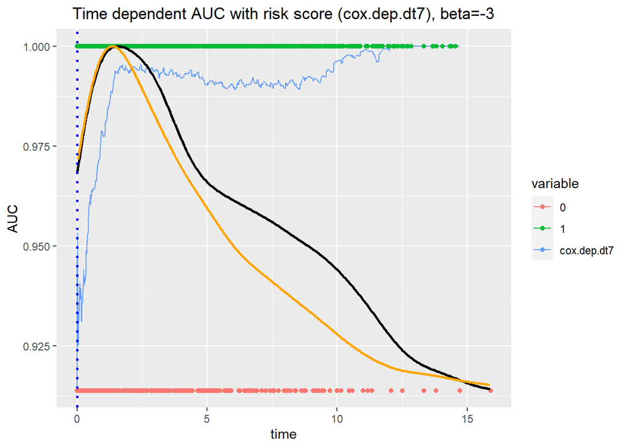

```r
dt7$censor1 <- ifelse(dt7$censor==1,
                    1,min(na.omit(ROC.risk.dep.dt7[["AUC"]])))
ggplot() +
  geom_line(data=res7, aes(x=time, y=value,
                            group=variable, color=variable)) +
  geom_point(data=dt7, aes(x=time, y=censor1, color=as.factor(censor))) +
  geom_line(data=data7_1, aes(x=time, y=density.adjusted),
            size=1, colour='black') +
  geom_line(data=data7_2, aes(x=time, y=density.adjusted),
            size=1, colour='orange') +
  scale_x_continuous(limits = c(0, max(dt7$time))) +
  geom_vline(xintercept = min(dt7$time[dt7$censor==1]),
             linetype="dotted", color = "blue", size=1) +
  ggtitle("Time dependent AUC with risk score (cox.dep.dt7), beta=-3") +
  xlab("time") + ylab("AUC") +
  theme(plot.title = element_text(hjust = 0.5))
```

#### Mean value of Time dependent AUC (cox.dep.dt7)

```r
mean(ROC.risk.dep.dt7[["AUC"]],na.rm=TRUE)
```

```
## [1] 0.9856055
```

#### simulation (repeat 100 times / time VS mean of AUC)

- simulation(repeat 100 times)은 다음과 같은 오류가 일어나는 관계로 아직 실시하지 않았습니다.

```
Error in eigen(hess1, symmetric = TRUE) :
'x'에 무한(infinite) 또는 결측(missing)값이 존재합니다.
```

## Example 2

## Generating simulation data

```r
lambda1 <- 0.01 # parameter for generate Y
lambda2 <- 0.2/lambda1 # parameter for generate C
beta0 <- 3 ; gamma0 <- 1 ; alpha0 <- 2 # true coefficients
Y <- c() # real survival time
C <- c() # censoring time
t <- c() # observed survival time
censor <- c() # censoring indicator
X <- c() # time invariant covariate : N(0,1^2)
M <- c() # interaction with time dependent term : U(0,1)
U1 <- c() # random variable from U(0,1) for generate Y
U2 <- c() # random variable from U(0,1) for generate C

for (i in 1:1000) {
  U1[i] <- runif(1)
  U2[i] <- runif(1)
  X[i] <- runif(1,min=0,max=1)
  M[i] <- runif(1,min=0,max=1)
  Y[i] <- (1/gamma0*M[i]*alpha0)*log(1-(gamma0*M[i]*alpha0/lambda1/exp(beta0*X[i]))*log(U1[i]))
  C[i] <- (lambda2)*(1-U2[i])
  t[i] <- min(Y[i],C[i])
  censor[i] <- ifelse(Y[i]<=C[i],1,0)
}

mean(1-censor) # censoring rate
```

```
## [1] 0.144
```

```r
dt7 <- data.frame(X=X, Y=Y, C=C, M=M, time=t, censor=censor)
head(dt7,10)
```

```
##             X         Y         C         M      time censor
## 1  0.13962624 8.4818868  5.586987 0.7387073 5.5869871      0
## 2  0.36282261 2.7469896 10.030001 0.4233735 2.7469896      1
## 3  0.28740259 1.0993512 18.418945 0.2078446 1.0993512      1
## 4  0.84568335 1.8603585 19.013935 0.9177287 1.8603585      1
## 5  0.01454805 8.6428191 10.125531 0.8298770 8.6428191      1
## 6  0.02420817 5.6620307 10.500635 0.9508677 5.6620307      1
## 7  0.99673008 0.4564006  5.029444 0.6570596 0.4564006      1
## 8  0.08815487 3.8310145  8.242100 0.4682644 3.8310145      1
## 9  0.56850896 4.9122453  4.558763 0.7572870 4.5587628      0
## 10 0.63269536 0.9018463  5.381672 0.4723858 0.9018463      1
```

```r
min(dt7$time[dt7$censor==1])
```

```
## [1] 9.115831e-06
```

### Time dependent AUC

### True model

- model : $h(t,x,m,z(t))=h_{0}(t)exp[\beta x + \gamma m z(t)]$
- $z(t)=\alpha t$
- $h_{0}(t)=\lambda$
- True coefficients : $\beta=3$, $\gamma=1$, $\alpha=2$
- https://stat.ethz.ch/R-manual/R-devel/library/mgcv/html/coxph.html

### Set Cox regression model

```r
cox.dep.dt7 <- gam(time ~ X + s(time,by=M), weights=censor, data=dt7, family=cox.ph)
summary(cox.dep.dt7)
```

```
##
## Family: Cox PH
## Link function: identity
##
## Formula:
## time ~ X + s(time, by = M)
##
## Parametric coefficients:
##   Estimate Std. Error z value Pr(>|z|)
## X   2.0715     0.1498   13.83   <2e-16 ***
## ---
## Signif. codes:  0 '***' 0.001 '**' 0.01 '*' 0.05 '.' 0.1 ' ' 1
##
## Approximate significance of smooth terms:
##             edf Ref.df Chi.sq p-value
## s(time):M 8.232  9.165  930.9  <2e-16 ***
## ---
## Signif. codes:  0 '***' 0.001 '**' 0.01 '*' 0.05 '.' 0.1 ' ' 1
##
## Deviance explained =   10%
## -REML = 3903.4  Scale est. = 1         n = 1000
```

```r
risk.dep.dt7 <- predict(object=cox.dep.dt7, newdata=dt7, type="link") # linear predictor (risk score)
dt7$risk.dep.dt7 <- risk.dep.dt7
ROC.risk.dep.dt7 <- timeROC(T=dt7$time,
                         delta=dt7$censor,marker=dt7$risk.dep.dt7,
                         cause=1,weighting="marginal",
                         times=dt7$time)
ROC.risk.dep.dt7
```

```
## Time-dependent-Roc curve estimated using IPCW  (n=1000, without competing risks).
##                        Cases Survivors Censored AUC (%)
## t=9.11583054458537e-06     0       999        1      NA
## t=0.598851814969657      217       749       34   97.20
## t=1.75827274264048       429       500       71   99.09
## t=3.65226786472566       639       250      111   99.19
## t=12.1308651609925       855         0      145      NA
##
## Method used for estimating IPCW:marginal
##
## Total computation time : 0.47  secs.
```

#### Make AUC data

```r
# uncensored
uncensored.density7 <- density(dt7$time[dt7$censor==1])
data7_1 <- data.frame(time=uncensored.density7[["x"]],
                    density=uncensored.density7[["y"]])
data7_1$density.adjusted <- (max(na.omit(ROC.risk.dep.dt7[["AUC"]]))-min(na.omit(ROC.risk.dep.dt7[["AUC"]])))*(uncensored.density7[["y"]]-min(uncensored.density7[["y"]]))/(max(uncensored.density7[["y"]])-min(uncensored.density7[["y"]]))+min(na.omit(ROC.risk.dep.dt7[["AUC"]]))

# censored
censored.density7 <- density(dt7$time[dt7$censor==0])
data7_2 <- data.frame(time=censored.density7[["x"]],
                    density=censored.density7[["y"]])
data7_2$density.adjusted <- (max(na.omit(ROC.risk.dep.dt7[["AUC"]]))-min(na.omit(ROC.risk.dep.dt7[["AUC"]])))*(censored.density7[["y"]]-min(censored.density7[["y"]]))/(max(censored.density7[["y"]])-min(censored.density7[["y"]]))+min(na.omit(ROC.risk.dep.dt7[["AUC"]]))

res7 <- data.frame(time=ROC.risk.dep.dt7[["times"]],
                    cox.dep.dt7=ROC.risk.dep.dt7[["AUC"]])
res7 <- melt(data = res7,
                   id.vars = "time",
                   measure.vars = c("cox.dep.dt7"))
```

#### Time dependent AUC plot with ggplot2 (cox.dep.dt7)

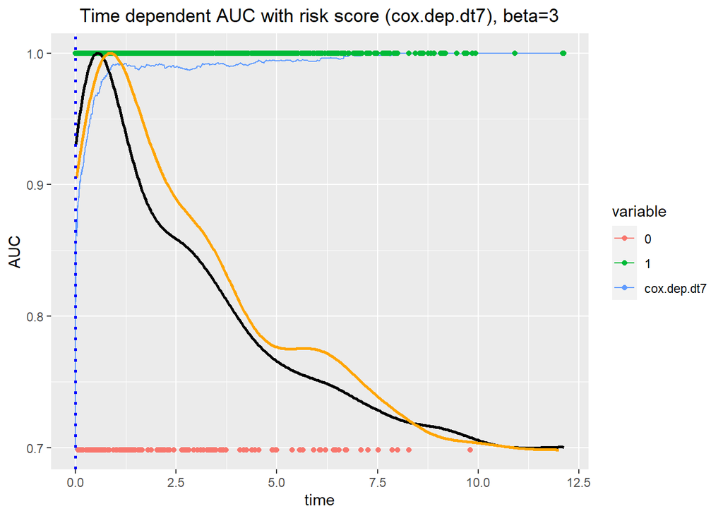

```r
dt7$censor1 <- ifelse(dt7$censor==1,
                    1,min(na.omit(ROC.risk.dep.dt7[["AUC"]])))
ggplot() +
  geom_line(data=res7, aes(x=time, y=value,
                            group=variable, color=variable)) +
  geom_point(data=dt7, aes(x=time, y=censor1, color=as.factor(censor))) +
  geom_line(data=data7_1, aes(x=time, y=density.adjusted),
            size=1, colour='black') +
  geom_line(data=data7_2, aes(x=time, y=density.adjusted),
            size=1, colour='orange') +
  scale_x_continuous(limits = c(0, max(dt7$time))) +
  geom_vline(xintercept = min(dt7$time[dt7$censor==1]),
             linetype="dotted", color = "blue", size=1) +
  ggtitle("Time dependent AUC with risk score (cox.dep.dt7), beta=3") +
  xlab("time") + ylab("AUC") +
  theme(plot.title = element_text(hjust = 0.5))
```

#### Mean value of Time dependent AUC (cox.dep.dt7)

```r
mean(ROC.risk.dep.dt7[["AUC"]],na.rm=TRUE)
```

```
## [1] 0.9724286
```

#### simulation (repeat 100 times / time VS mean of AUC)

- simulation(repeat 100 times)은 다음과 같은 오류가 일어나는 관계로 아직 실시하지 않았습니다.

```
Error in eigen(hess1, symmetric = TRUE) :
'x'에 무한(infinite) 또는 결측(missing)값이 존재합니다.
```